# 데이터 과학을 위한 저작도구

R 마크다운 실무

실무에서 많이 사용되는 R 마크다운 구문이 잘 정리된 블로그가 있어 [현대적인 과학논문 저작](http://statkclee.github.io/modern-scientific-authoring/index-kr.html)의 내용에 더하여 R을 주로 사용하는 사용자에게 유용할 것으로 사료되어 블로그의 내용을 중심으로 내용을 정리하였고 몇가지 유용한 사례도 추가하였다. 특히, [Pimp my RMD: a few tips for R Markdown by Yan Holtz - 11 April 2018](https://holtzy.github.io/Pimp-my-rmd/) 내용이 많이 포함되어 있다. PIMP는 “**P**ut **I**n **M**y **P**ocket”으로 추청된다. 또한, [Pimp my RMD: a few tips for R Markdown by Yan Holtz - 10 December 2019](https://holtzy.github.io/Pimp-my-rmd/) 거의 1년만에 업데이트 되면서 추가로 추가된 사항도 많이 있다.

# 1 문서 형식 (Text formating) [^1]

R 마크다운을 사용해서 쉽게 아무것도 없는 텍스트를 **강조**, *이태릭*은 물론이고 링크도 추가할 수 있는데 자세한 내용은 [영문 컨닝쪽지(RStudio cheatsheet)](https://www.rstudio.com/wp-content/uploads/2015/02/rmarkdown-cheatsheet.pdf)에서 확인 가능하고 한글은 [R 마크다운 컨닝쪽지](https://github.com/rstudio/cheatsheets/raw/master/translations/korean/rmarkdown-cheatsheet-kr.pdf)에서 확인 가능하다.

```r
R 마크다운을 사용해서 쉽게 아무것도 없는 텍스트를 **강조**, *이태릭*은 물론이고 [링크](www.r-graph-gallery.com)도 추가할 수 있는데 자세한 내용은 [영문 컨닝쪽지(RStudio  cheatsheet)](https://www.rstudio.com/wp-content/uploads/2015/02/rmarkdown-cheatsheet.pdf)에서 확인 가능하고 한글은 [R 마크다운 컨닝쪽지](https://github.com/rstudio/cheatsheets/raw/master/translations/korean/rmarkdown-cheatsheet-kr.pdf)에서 확인 가능하다.
```

# 2 수평선

문서에 수평선을 넣어 문장이나 문단을 구분할 때 유용하게 사용될 수 있는데 이런 경우 별 3개로 간단히 처리가 된다.

```r
***
```

# 3 제목 자동번호 넣기

큰제목, 중간제목, 작은제목, … 표현하는데 `#`, `##`, `###`을 사용하는데 각각에 대해서 번호를 넣고자 하는 경우 YAML 헤더에 `number_sections: TRUE`를 넣어 사용하면 된다.

```r
---
layout: page
title: 데이터 과학을 위한 저작도구
subtitle: R 마크다운 실무
output:
  html_document:
    theme: default
    toc: yes
    toc_float: true
    highlight: tango
    code_folding: show
    number_sections: TRUE
mainfont: NanumGothic
---

# 문서 형식(format) {#rmd}
## 수평선 {#horizontal-line}
## 제목 자동번호 넣기 {#auto-numbering}
```

# 4 줄간격 넓히기

줄간격을 넓혀 띄어쓰기를 하고자 할 경우 `<br>`을 넣어 준다.

```r
헌법개정안 대통령 발의
<br><br><br>
국회에서 응답
```

헌법개정안 대통령 발의  
국회에서 응답

# 5 이미지 가운데 정렬

이미지를 가운데 정렬시키는데 다음 코드를 사용한다. `{#id .class width="50%"}`을 통해 이미지 크기도 조정할 수 있다.

```r
<center>
![이미지 설명을 단다.](fig/00_cover_boy_girl.png){#id .class width="50%"}
</center>
```

결과는 다음과 같다.

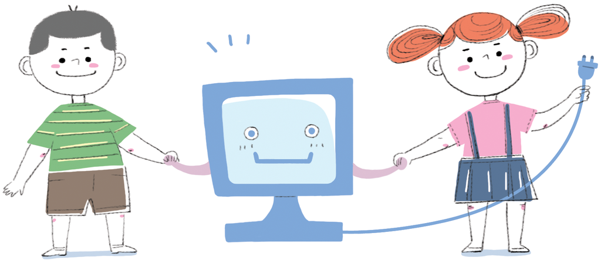

# 6 이미지 주변 공백

이미지 주변 공백이 문제된다면 [Anna Quaglieri](https://twitter.com/annaquagli)님이 제안해 주신 `fig.asp` 인자값을 조정하여 해결한다. 예를 들어, `fig.asp=0.50` 값을 사용한다.

- fig.width=3,
- fig.height=3
- fig.align=‘center’
- cache=TRUE
- fig.cap=“Lovely Kangaroo from the Mornington Peninsula.”
- fig.asp=0.50

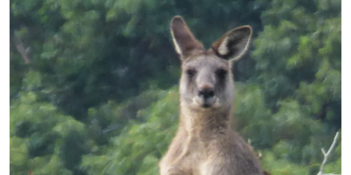

Lovely Kangaroo from the Mornington Peninsula.

```r
library(png)
library(grid)
img <- readPNG("fig/kan.png")
grid.raster(img)
```

# 7 Footer and header

HTML 문서의 `header.html`, `footer.html` HTML 파일에 관련된 내용을 저장시키고 나서 `.Rmd` 파일에 이를 반영시킨다. 필요한 경우, [fontawesome.com](https://fontawesome.com/) 웹사이트에서 적절한 아이콘을 선택한다.

```r
&nbsp;
<hr />
<p style="text-align: center;"> 데이터 과학자 <a href="https://github.com/statkclee/">이광춘</a> 저작</p>
<p style="text-align: center;"><span style="color: #808080;"><em>kwangchun.lee.7@gmail.com</em></span></p>
<!-- Add icon library -->
<link rel="stylesheet" href="https://cdnjs.cloudflare.com/ajax/libs/font-awesome/4.7.0/css/font-awesome.min.css">
<!-- Add font awesome icons -->
<p style="text-align: center;">
  <a href="https://education.rstudio.com/trainers/people/lee+kwangchun/" class="fa fa-registered"></a>
    <a href="https://www.facebook.com/groups/tidyverse/" class="fa fa-facebook"></a>
    <a href="https://www.linkedin.com/in/kwangchunlee/" class="fa fa-linkedin"></a>
    <a href="https://github.com/statkclee/" class="fa fa-github"></a>
</p>
&nbsp;
```

`footer.html` 파일에 상기 내용을 저장시키고 나서, `.Rmd` 파일 YAML 영역에 다음과 같이 포함시키도록 지정한다.

```r
layout: page
title: "데이터 과학을 위한 저작도구"
subtitle: "**R 마크다운 실무**"
output:
  html_document:
    includes:
      after_body: footer.html
    theme: default
    toc: yes
    toc_float: true
    highlight: tango
    code_folding: show
    number_sections: TRUE
mainfont: NanumGothic
```

`footer.html` 파일을 반영한 후 모습은 다음과 같다.

[figure not shown]

# 8 이미지 캡션(caption)

다음과 같이 `fig.cap` 인자를 지정하여 이미지에 짧은 해설문(caption)을 단다.

```r
{r, fig.align="center", fig.width=6, fig.height=6, fig.cap="그림 1: 정말 짧은 해설문 을 caption이라고 영어로 번역한다."}
```

```r
mpg %>%
  ggplot( aes(x=reorder(class, hwy), y=hwy, fill=class)) +
    geom_boxplot() +
    xlab("class") +
    theme(legend.position="none")
```

[output not shown]

# 9 고급 이미지 캡션(caption)

# 10 특정 문단 강조

특정 문단을 강조하고자 할 경우 다음과 같이 `<style> ... </style>`을 정의하고 `<div class = "blue"> ... </div>`로 뽑아내서 사용한다.

```r
<style>
div.blue { background-color:#e6f0ff; border-radius: 5px; padding: 10px;}
</style>
<div class = "blue">

- R Meetup 10회
- 발표해주시고 참여해주신 분들 감사드립니다.

</div>
```

- R Meetup 10회
- 발표해주시고 참여해주신 분들 감사드립니다.

## 10.1 $LaTeX$ 수식

수학공식 등 수식을 넣을 경우 `$` 사이에 $LaTeX$ 수식을 넣어 작성한다.

$$A = (\pi * \lambda \times r^{4}) / \alpha$$

```r
$A = (\pi * \lambda \times r^{4}) / \alpha $
```

## 10.2 탭(tab), 버튼 사용

유사한 내용을 쭉 나열하는 것보다 탭이나 버튼을 사용하여 지면을 절약하고자 할 때 유용한다.

# 11 R Meetup

## 11.1 첫번째 R Meetup

```r
## R Meetup {.tabset .tabset-fade .tabset-pills}

***

### 첫번째 R Meetup
R Meetup의 성공을 기원합니다.

### 두번째 R Meetup
많은 분들이 모였습니다.

### 세번째 R Meetup
우와 ~~~
```

## 11.2 두번째 R Meetup

많은 분들이 모였습니다.

## 11.3 세번째 R Meetup

# 12 그래프

## 12.1 그래프를 나란히

그래프를 나란히 놓고자 할 경우 다음과 같이 코드를 작성한다.

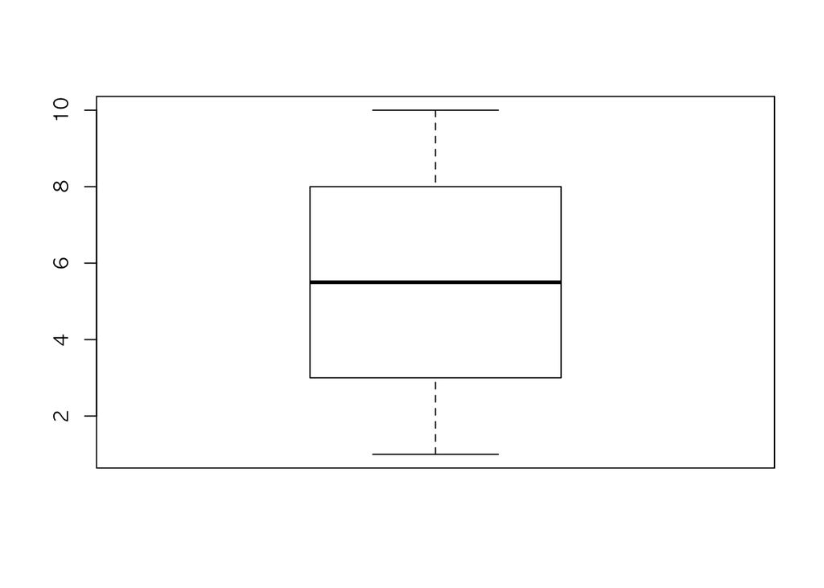

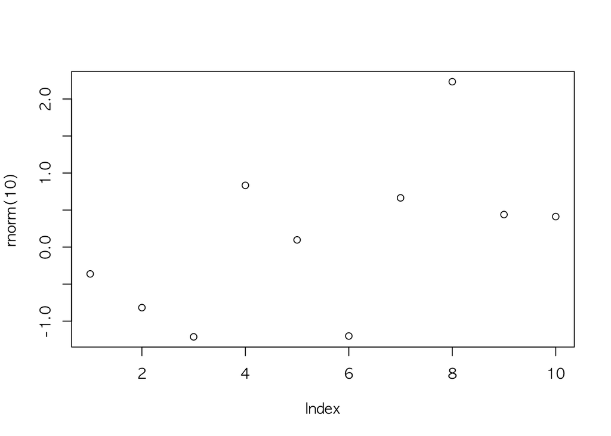

```r
boxplot(1:10)

plot(rnorm(10))
```

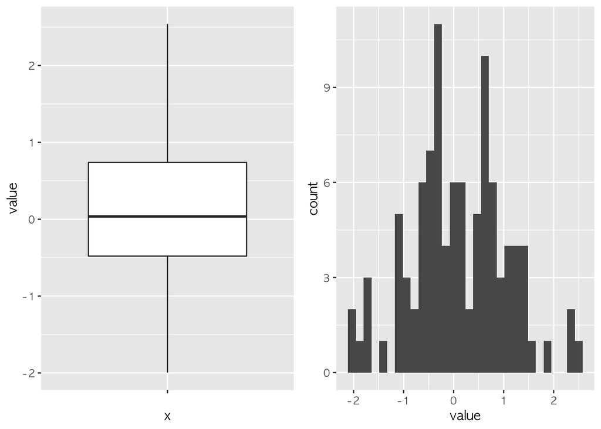

```r
library(gridExtra)
library(tidyverse)

smpl_df <- rnorm(100) %>% as_tibble()

box_g <- ggplot(smpl_df, aes(x="", y=value)) +
    geom_boxplot()

hist_g <- ggplot(smpl_df, aes(x=value)) +
    geom_histogram()


grid.arrange(box_g, hist_g, ncol=2)
```

## 12.2 그래프 캡션(caption)

그래프 캡션(caption)을 넣는 방식은 다음과 같이 R 코드 덩어리(chunk)에 `fig.cap`에 명세를 한다.

`{r ggplot-caption, fig.align="center", fig.width=6, fig.height=6, fig.cap="그림: 소형차가 연비가 좋다."}`

```r
mpg %>%
  ggplot( aes(x=reorder(class, hwy), y=hwy, fill=class)) +
    geom_boxplot() +
    xlab("class") +
    theme(legend.position="none")
```

[output not shown]

# 13 R 코드

## 13.1 코드를 나란히

`<div>` 태글 사용하여 `col-md-6` 값을 조정해서 이등할 수도 있고, `col-md-4`를 3회 사용하여 3등분하는 것도 가능하다.

**입력사례**

열심히… 입력합니다.

**복사하여 붙여넣기**

컨트롤+C , 컨트롤+V

```r
<div class = "row">
  <div class = "col-md-6">
**입력사례**

열심히... 입력합니다.

  </div>
  <div class = "col-md-6">
**복사하여 붙여넣기**

컨트롤+C , 컨트롤+V

  </div>
</div>
```

[^1]: [Pimp my RMD: a few tips for R Markdown, by Yan Holtz - 11 April 2018](https://holtzy.github.io/Pimp-my-rmd/)

데이터 과학자 [이광춘](https://github.com/statkclee/) 저작

*kwangchun.lee.7@gmail.com*